# RED WINE EXPLORATION by Yukti Sareen

# Multivariate Analysis

### Talk about some of the relationships you observed in this part of the investigation. Were there features that strengthened each other in terms of looking at your feature(s) of interest?

The multivariate analysis result shows that there are not so many strong segmentation by quality. However there are still useful distribution and relationship in quality level 5 and 6.

# Final Plots and Summary

### Plot One

[figure not shown]

### Plot Two

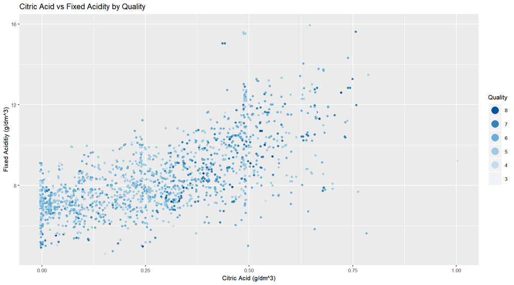

### Plot Three

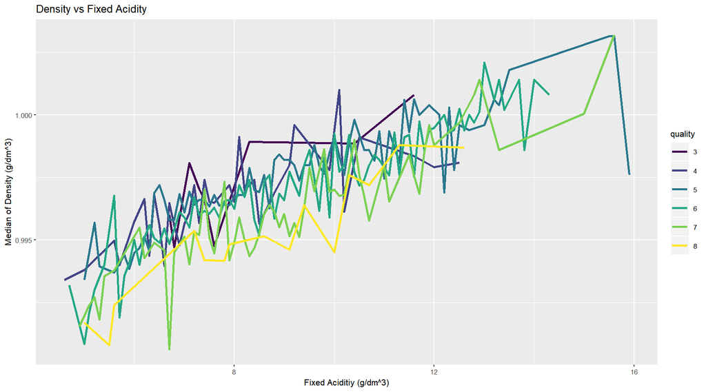

### Description Three

Final graph is the line graph with fixed acidity to median of density. Overall, density is strong correlated with fixed acidity which proved by upwarding trend. However, there are some interesting finding.Talk about quality level 3 first. When fixed acidity from near 8 to 10 , the density does not go upwpard and except the zone mention above, it still perform a good increase trend. Second, we can find that in most time, the line of quality level 8 are always in the bottom, and line of quality level 7 along with level 8. This phenomenon indicate that high quality wines are along with lower density than lower quality line when fixed acidity is fixed.

# Reflection

> This project took the longest time to analyse and display the plots. I had fun exploring and plotting meaningful graphs and understanding the corelation when plotting 2 variabels against three variables. This gave an insight on factors that affect the quality of the wine. For future work, I would like to play around the alcohol content since alcohol and desnsity have strong relation and eventually build a linear model.